# Neteja i anàlisis de les dades

## 5.2 Comprovació de la normalitat i homogeneïtat de la variància.

Per analitzar la normalitat de les dades tenim diversos test estadístics els quals busquen respondre el següent contrast d’hipòtesis:

Ho: normalitat H1: no normalitat

```
## Variables NO normals:
## PassengerId, Age,
## Fare,
```

Pel que fa a la homogeneitat de la variància:

Ho: hi ha homogeneïtat de variàncies H1: les variables són heteroblàstiques

Apliquem aquest test per a les variables numèriques, indicant que els grups que volem testar són els de la variables sobrevivència:

- Age:

```
## Levene's Test for Homogeneity of Variance (center = median)
##        Df F value  Pr(>F)
## group   1  5.5007 0.01923 *
##       889
## ---
## Signif. codes:  0 '***' 0.001 '**' 0.01 '*' 0.05 '.' 0.1 ' ' 1
```

```
## Levene's Test for Homogeneity of Variance (center = median)
##        Df F value    Pr(>F)
## group   1    45.1 3.337e-11 ***
##       889
## ---
## Signif. codes:  0 '***' 0.001 '**' 0.01 '*' 0.05 '.' 0.1 ' ' 1
```

Amb el p-valor < 0.05 rebutgem la hipòtesi nul·la i per tant direm que no hi ha homogeneïtat de variàncies entre el grup de supervivents i els que moren en funció de la tarifa que van pagar.

## 5.3 Aplicació de proves estadístiques

Farem una comparacio de mitjanes per comprovar si els dos grups definits son o no diferents:

H0: igualtat de mitjanes m1: mitjanes diferents

```
##
##  Wilcoxon rank sum test with continuity correction
##
## data:  viu$Age and mort$Age
## W = 89538, p-value = 0.2434
## alternative hypothesis: true location shift is not equal to 0
```

com que el p-valor és molt elevat direm que ambdos grups tenen mitjanes que es poden considerar iguals.

- Preu tiquet, la variable tampoc es considerava normal per tant apliquem el mateix test, i el mateix contrast:

```
##
##  Wilcoxon rank sum test with continuity correction
##
## data:  viu$Fare and mort$Fare
## W = 129952, p-value < 2.2e-16
## alternative hypothesis: true location shift is not equal to 0
```

En aquest cas les mitjanes d’ambdos grups no es poden considerar iguals, de fet si mirem una descrivtiva bivariant veurem que els que sovreviuen pagaven tarifes més altres:

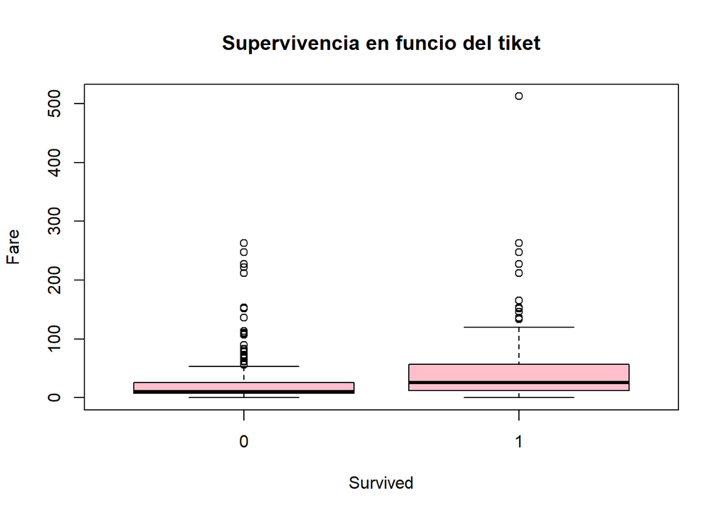

Veiem en aquets boxplots que la poblacio que sovreviu (1) són gent que va pagar un preu més elevat.

# 6 Representació dels resultats a partir de taules i gràfiques.

# 7 Resolució del problema.